# Introduction à GeoPandas

## Projections

Chaque « GeoSeries » a son système de référence de coordonnées (CRS) accessible sur « GeoSeries.crs ». Le CRS indique à GeoPandas où se trouvent les coordonnées des géométries à la surface de la Terre. Dans certains cas, le CRS est géographique, ce qui signifie que les coordonnées sont en latitude et en longitude. Dans ces cas, son CRS est WGS84, avec le code d'autorité « EPSG:4326 ». Voyons la projection de nos communes de Bouira `GeoDataFrame`.

```python
gdf.crs
```

```
<Projected CRS: EPSG:3857>
Name: WGS 84 / Pseudo-Mercator
Axis Info [cartesian]:
- X[east]: Easting (metre)
- Y[north]: Northing (metre)
Area of Use:
- name: World between 85.06°S and 85.06°N.
- bounds: (-180.0, -85.06, 180.0, 85.06)
Coordinate Operation:
- name: Popular Visualisation Pseudo-Mercator
- method: Popular Visualisation Pseudo Mercator
Datum: World Geodetic System 1984 ensemble
- Ellipsoid: WGS 84
- Prime Meridian: Greenwich
```

Les géométries sont au format « EPSG:3857 » avec les coordonnées en metre. Nous pouvons facilement re-projeter une `GeoSeries` sur un autre CRS, comme `EPSG:4326` en utilisant `GeoSeries.to_crs()`.

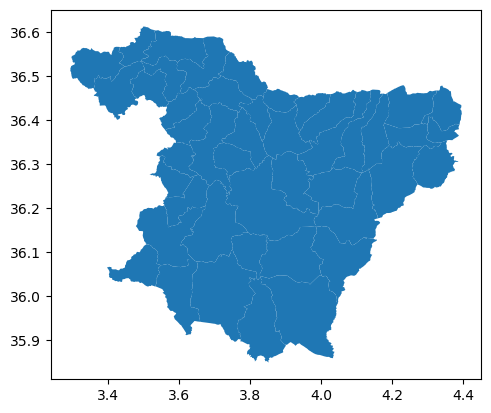

```python
gdf = gdf.set_geometry("geometry")
communes_4326 = gdf.to_crs("EPSG:4326")
communes_4326.plot()
```

```python
communes_4326.crs
```

```
<Geographic 2D CRS: EPSG:4326>
Name: WGS 84
Axis Info [ellipsoidal]:
- Lat[north]: Geodetic latitude (degree)
- Lon[east]: Geodetic longitude (degree)
Area of Use:
- name: World.
- bounds: (-180.0, -90.0, 180.0, 90.0)
Datum: World Geodetic System 1984 ensemble
- Ellipsoid: WGS 84
- Prime Meridian: Greenwich
```

Avertissement

User guide

See more on [projections](https://geopandas.org/docs/user_guide/projections.rst) in the user guide.

## Et ensuite ?

Avec GeoPandas, nous pouvons faire bien plus que ce qui a été introduit jusqu'à présent, des [agrégations](https://geopandas.org/en/stable/docs/user_guide/aggregation_with_dissolve.html) aux [jointures spatiales](https://geopandas.org /docs/user_guide/mergingdata.rst), au [géocodage](https://geopandas.org/en/stable/docs/user_guide/geocoding.html), et [beaucoup plus](https://geopandas.org/gallery/index. premier).

Rendez-vous sur le [guide de l'utilisateur](https://geopandas.org/en/stable/docs/user_guide.html) pour en savoir plus sur les différentes fonctionnalités de GeoPandas, les [Exemples](https://geopandas.org/gallery/index. rst) pour voir comment ils peuvent être utilisés, ou à la [référence API](https://geopandas.org/en/stable/docs/reference.html) pour plus de détails.